# assignment

Yue Xiong

2022-08-23

## Step1: Data Preparation

In step1, we aim to read in the original datasets and the synthetic dataset while aligning the variables especially set in the syn dataset. Attempting to compare the two datasets, we should also concatenate the original datasets vertically with variables all set as the same. Also, we are filtering out all the non-GPDR countries.

```r
# set the working directory
wd <- getwd()
setwd(wd)
# read in the synthetic dataset
syn_data <- read.csv(file = "./syn_2020-08-02_2020-08-08.csv")
# and on macos
head(syn_data)
```

|  | sample_weight | B1_1 | B1_2 | B1_3 | B1_4 | B1_5 | B1_6 | B1_7 | B1_8 | B1_9 | B1_10 | B1_11 | B1_12 | B1_13 | B1b_x1 | B1b_x2 | B1b_x3 | B1b_x4 | B1b_x5 | B1b_x6 | B1b_x7 | B1b_x8 | B1b_x9 | B1b_x10 | B1b_x11 | B1b_x12 | B1b_x13 | B3 | B5 | … |
| --- | --- | --- | --- | --- | --- | --- | --- | --- | --- | --- | --- | --- | --- | --- | --- | --- | --- | --- | --- | --- | --- | --- | --- | --- | --- | --- | --- | --- | --- | --- |
| 1 | 20424.14 | 2 | 2 | 2 | 2 | 2 | 2 | 2 | 2 | 2 | 2 | 2 | 2 | 2 | -99 | -99 | -99 | -99 | -99 | -99 | -99 | -99 | -99 | -99 | -99 | -99 | -99 | 2 | -99 | … |
| 2 | 20424.14 | 2 | 2 | 2 | 1 | 2 | 2 | 2 | 2 | 2 | 2 | 2 | 2 | 2 | -99 | -99 | -99 | 1 | -99 | -99 | -99 | -99 | -99 | -99 | -99 | -99 | -99 | 2 | -99 | … |
| 3 | 20424.14 | 2 | 1 | 1 | 2 | 2 | 1 | 2 | 2 | 2 | 2 | 2 | 2 | 2 | -99 | 2 | 1 | -99 | -99 | 2 | -99 | -99 | -99 | -99 | -99 | -99 | -99 | 2 | -99 | … |
| 4 | 20424.14 | 2 | 2 | 2 | 2 | 2 | 2 | 2 | 2 | 2 | 2 | 2 | 2 | 2 | -99 | -99 | -99 | -99 | -99 | -99 | -99 | -99 | -99 | -99 | -99 | -99 | -99 | 2 | -99 | … |
| 5 | 20424.14 | 2 | 1 | 2 | 1 | 1 | 1 | 1 | 1 | 1 | 2 | 2 | 1 | 2 | -99 | 2 | -99 | 2 | 2 | 2 | 2 | 2 | 2 | -99 | -99 | 2 | -99 | 2 | -99 | … |
| 6 | 20424.14 | 2 | 2 | 2 | 1 | 2 | 2 | 2 | 2 | 2 | 2 | 2 | 2 | 2 | -99 | -99 | -99 | 2 | -99 | -99 | -99 | -99 | -99 | -99 | -99 | -99 | -99 | 2 | -99 | … |

```r
# syn_data <- read_csv("./syn_2020-08-02_2020-08-08.csv", show_col_types = FALSE)
# rename "sample weight" to "weight" to avoid conflicts
colnames(syn_data)[colnames(syn_data) == "sample_weight"] <- "weight"

# columns to be included from the original dataset
cols_list <- colnames(syn_data)

# initialize an empty dataset list
ori_dataset <- list()

for (i in 1:7){
ori_dataset[[i]] <- vroom(list.files(pattern = "*_full.csv$")[i],
                    show_col_types = FALSE) %>%
                    select(all_of(cols_list))
}

dim(ori_dataset[[2]])[2] == dim(syn_data)[2]
```

```
## [1] TRUE
```

```r
# check whether 2 dimensions coincide with each other

# bind the original datasets from 0802 to 0808 vertically
bindori_dataset <- bind_rows(ori_dataset)
bindori_dataset <- as.data.frame(bindori_dataset)
dim(bindori_dataset)
```

```
## [1] 996174     92
```

```r
dim(syn_data)
```

```
## [1] 100000     92
```

Now we need to check all the `gpdr` countries and only do the alignment.

```r
gpdr_countries_data <- NA
gpdr_countries_data <- read.csv(file = "./gpdr.csv", sep = ",")
head(gpdr_countries_data$Country_GID, n = 10L)
```

```
##  [1] "AUT" "AUT" "AUT" "AUT" "AUT" "AUT" "AUT" "AUT" "AUT" "BEL"
```

```r
country_name <- unique(as.character(gpdr_countries_data$Country_GID))
length(country_name)
```

```
## [1] 27
```

```r
length(unique(bindori_dataset$GID_0))
```

```
## [1] 218
```

```r
bindori_dataset_filtered <- bindori_dataset %>%
                                        filter(GID_0 %in% country_name)


syn_data_filtered <- syn_data %>%
                          filter(GID_0 %in% country_name)
length(unique(bindori_dataset_filtered$GID_0)) == length(unique(syn_data_filtered$GID_0))  # check whether we have the same number of countries for both synthetic and original datasets.
```

```
## [1] TRUE
```

## Step2: Evaluating the utility of the syn data

In step2, we try to evaluate the utility of the synthetic dataset with one-way marginal and two-way marginal measures.

- As for the one-way utility, the syn dataset is measured with the compare plots and pMSE/S_pMSE.
- And for the two-way utility, the synthetic dataset is evaluated with the utility tables which takes up a heatmap fashion/manner.

```r
# subset some example columns and try plotting the compare histograms
# these are symptoms variables
symptoms <- c("B3","B4","B1_1","B1_2","B1_3","B1_4","B1_5","B1_6","B1_7",
              "B1_8","B1_9","B1_10","B1_12","B1_13",
              "B1b_x1","B1b_x2","B1b_x3","B1b_x4","B1b_x5","B1b_x6","B1b_x7",
              "B1b_x8","B1b_x9","B1b_x10","B1b_x12","B1b_x13","B2")

# these are testing variables
testing <- c("B7")

# Columns `B0`, `B8a`, `B15_1`, `B15_2`, `B15_3`, etc. don't exist

ori_dataset_symptoms <- as.data.frame(bindori_dataset_filtered[, symptoms])
syn_dataset_symptoms <- as.data.frame(syn_data_filtered[, symptoms])

ori_dataset_testing <- as.data.frame(bindori_dataset_filtered$B7)
syn_dataset_testing <- as.data.frame(syn_data_filtered$B7)
```

### (1). one-way marginals using compare()

```
##
## Comparing percentages observed with synthetic
##
## $B3
##                 -99        1        2
## observed  0.5424531 4.903592 94.55396
## synthetic 0.1320000 4.531000 95.33700
```

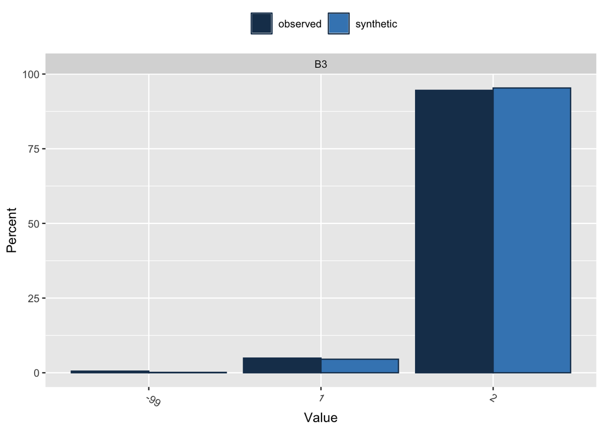

```
##
## Selected utility measures:
##        pMSE   S_pMSE
## B3 0.000172 214.2633
```

```r
## for var B3 -> symptoms
compare(object = data.frame(B3 = syn_dataset_symptoms$B3),
        data = data.frame(B3 = ori_dataset_symptoms$B3),
        vars = c("B3"), cont.na = NULL,
        msel = NULL, stat = "percents", breaks = 20,
        nrow = 2, ncol = 2, rel.size.x = 1,
        utility.stats = c("pMSE", "S_pMSE"),
        cols = c("#1A3C5A","#4187BF"),
        plot = TRUE, table = TRUE)
```

```
##
## Comparing percentages observed with synthetic
```

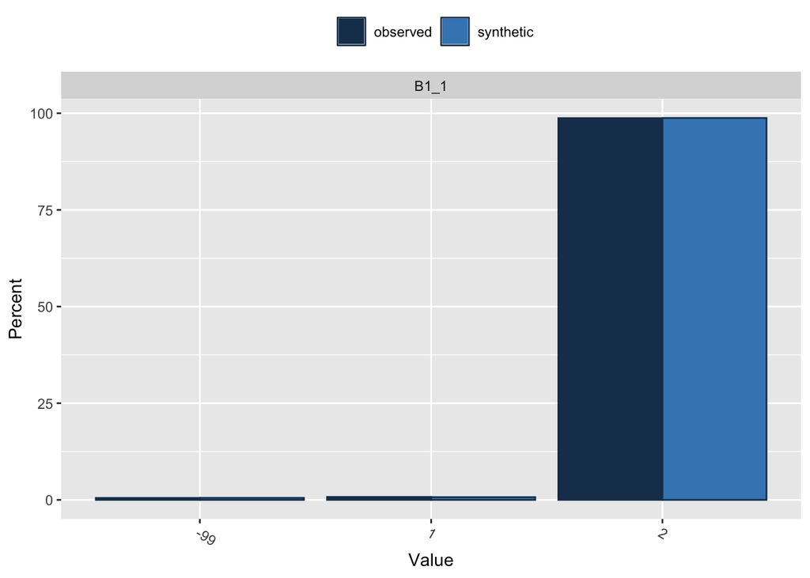

```
##
## Selected utility measures:
##       pMSE   S_pMSE
## B1_1 2e-06 2.429377
```

```r
## for var B1_1 -> symptoms
compare(object = data.frame(B1_1 = syn_dataset_symptoms$B1_1),
        data = data.frame(B1_1 = ori_dataset_symptoms$B1_1),
        vars = "B1_1", cont.na = NULL,
        msel = NULL, stat = "percents", breaks = 20,
        nrow = 2, ncol = 2, rel.size.x = 1,
        utility.stats = c("pMSE", "S_pMSE"),
        cols = c("#1A3C5A","#4187BF"),
        plot = TRUE, table = FALSE)
```

```
##
## Comparing percentages observed with synthetic
```

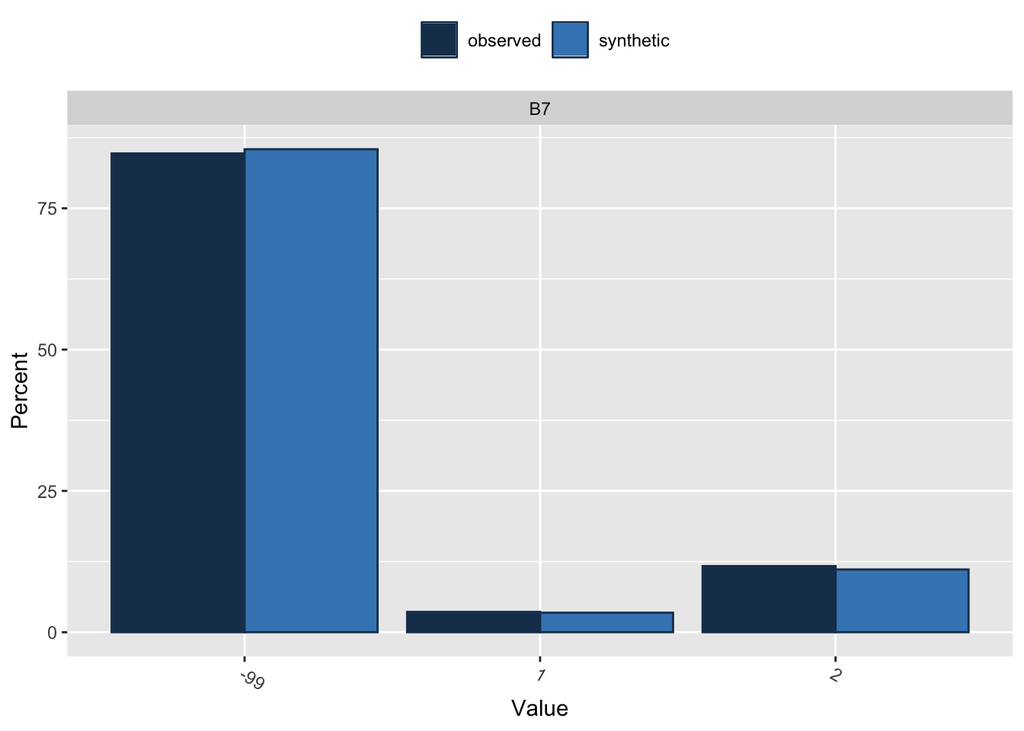

```
##
## Selected utility measures:
##       pMSE   S_pMSE
## B7 1.8e-05 22.01889
```

```r
## for var B7 -> testing
compare(object = data.frame(B7 = syn_data_filtered$B7),
        data = data.frame(B7 = bindori_dataset_filtered$B7),
        vars = "B7", cont.na = NULL,
        msel = NULL, stat = "percents", breaks = 20,
        nrow = 2, ncol = 2, rel.size.x = 1,
        utility.stats = c("pMSE", "S_pMSE"),
        cols = c("#1A3C5A","#4187BF"),
        plot = TRUE, table = FALSE)
```

```
##
## Comparing percentages observed with synthetic
```

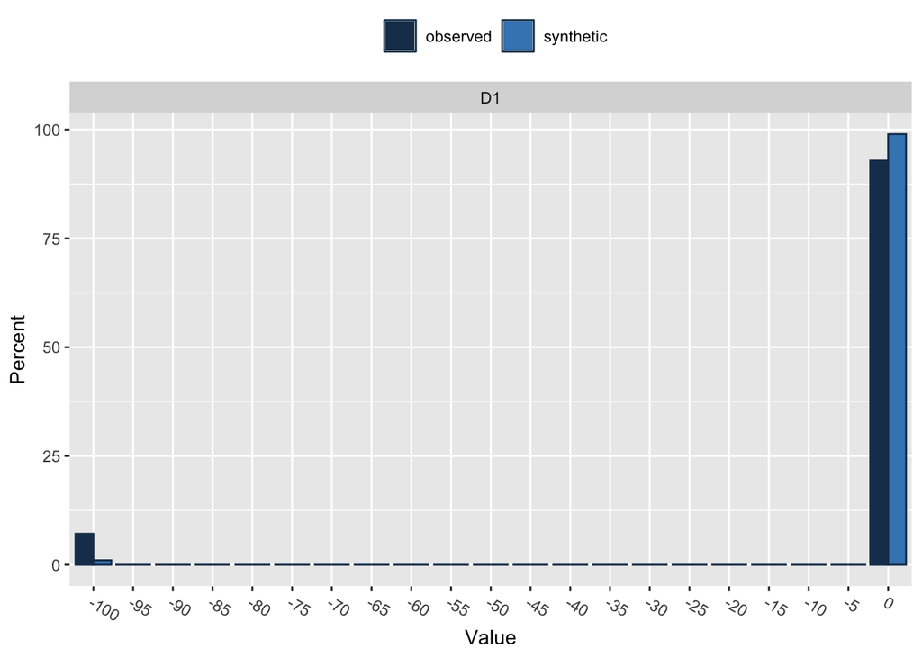

```
##
## Selected utility measures:
##        pMSE   S_pMSE
## D1 0.000835 2076.806
```

```r
## for var D1 -> module B
compare(object = data.frame(D1 = syn_data_filtered$D1),
        data = data.frame(D1 = bindori_dataset_filtered$D1),
        vars = "D1", cont.na = NULL,
        msel = NULL, stat = "percents", breaks = 20,
        nrow = 2, ncol = 2, rel.size.x = 1,
        utility.stats = c("pMSE", "S_pMSE"),
        cols = c("#1A3C5A","#4187BF"),
        plot = TRUE, table = FALSE)
```

```
##
## Comparing percentages observed with synthetic
```

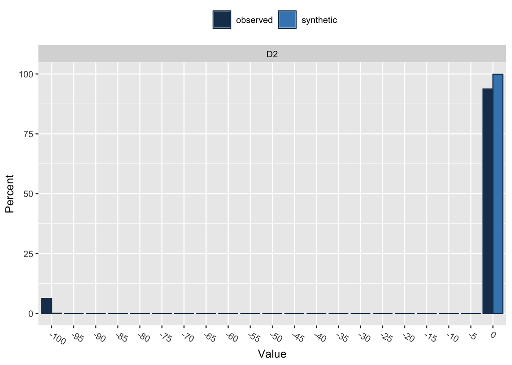

```
##
## Selected utility measures:
##        pMSE   S_pMSE
## D2 0.000665 1654.444
```

```r
## for var D2 -> module B
compare(object = data.frame(D2 = syn_data_filtered$D2),
        data = data.frame(D2 = bindori_dataset_filtered$D2),
        vars = "D2", cont.na = NULL,
        msel = NULL, stat = "percents", breaks = 20,
        nrow = 2, ncol = 2, rel.size.x = 1,
        utility.stats = c("pMSE", "S_pMSE"),
        cols = c("#1A3C5A","#4187BF"),
        plot = TRUE, table = FALSE)
```

```
##
## Comparing percentages observed with synthetic
```

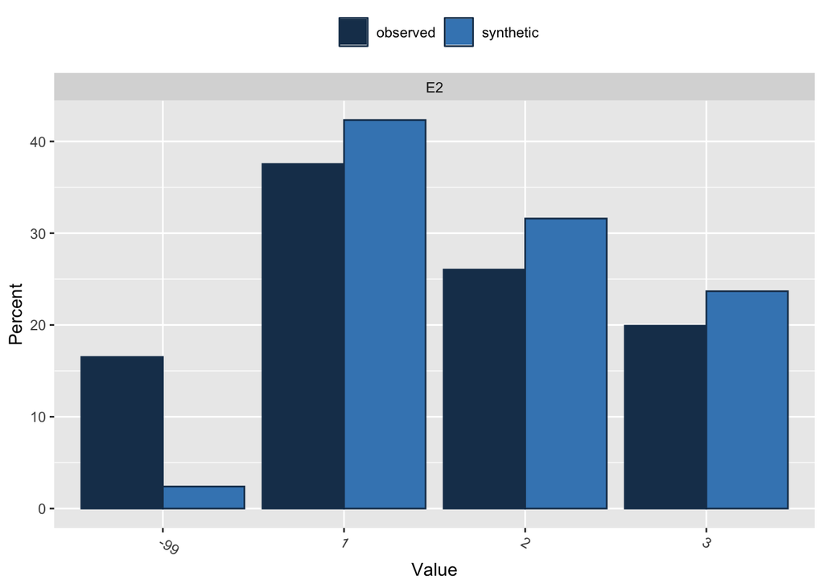

```
##
## Selected utility measures:
##        pMSE   S_pMSE
## E2 0.007316 6065.024
```

```r
## for var E2 -> demographics
compare(object = data.frame(E2 = syn_data_filtered$E2),
        data = data.frame(E2 = bindori_dataset_filtered$E2),
        vars = "E2", cont.na = NULL,
        msel = NULL, stat = "percents", breaks = 20,
        nrow = 2, ncol = 2, rel.size.x = 1,
        utility.stats = c("pMSE", "S_pMSE"),
        cols = c("#1A3C5A","#4187BF"),
        plot = TRUE, table = FALSE)
```

```
##
## Comparing percentages observed with synthetic
```

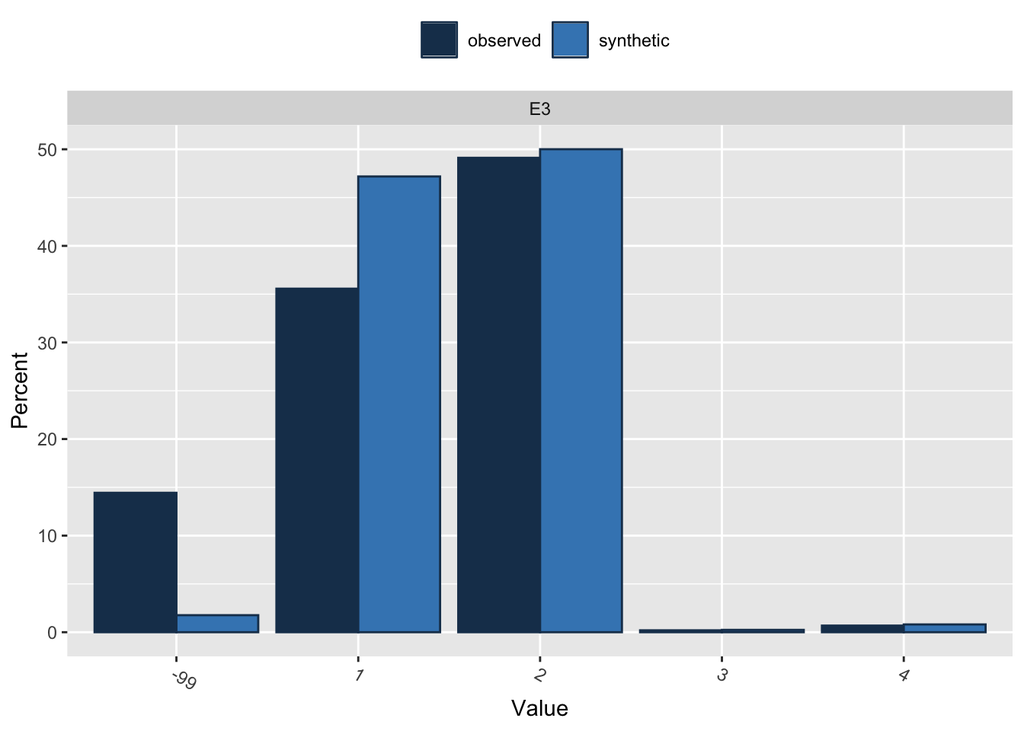

```
##
## Selected utility measures:
##        pMSE   S_pMSE
## E3 0.007331 4558.638
```

```r
## for var E3 -> demographics
compare(object = data.frame(E3 = syn_data_filtered$E3),
        data = data.frame(E3 = bindori_dataset_filtered$E3),
        vars = "E3", cont.na = NULL,
        msel = NULL, stat = "percents", breaks = 20,
        nrow = 2, ncol = 2, rel.size.x = 1,
        utility.stats = c("pMSE", "S_pMSE"),
        cols = c("#1A3C5A","#4187BF"),
        plot = TRUE, table = FALSE)
```

### (2). two-way marginals with utility.tables()

In this part, we focus on the utility in the two-way manner/fashion.